# 基于词典法的财经新闻情感分析

## 准备工作

```r
# 清除工作环境
cat("\014"); rm(list=ls())
```

```r
library(kableExtra)   # 加载kableExtra包，用于在html中展示滚动表格
library(jiebaRD)      # 加载R包 用于jieba分词
library(jiebaR)       # 加载R包 用于jieba分词
library(reshape2)     # 加载包用于整合分词后的文本
library(wordcloud2)   # 加载程序包用于绘制词云图
library(ggplot2)      # 加载程序包进行图形绘制
```

## 任务一：数据读入

设置好你的工作路径，找到评论数据集data.csv。读入该数据，命名为news_data。使用head()查看数据的基本情况。

其中，index表示的是该新闻的编号，title表示的是该新闻的标题，time表示的是该新闻发表的时间，author表示的是该新闻的作者或发表机构，content表示的是该新闻的具体内容。

由于新闻文本较长，此处使用kableExtra包进行滚动文本查看。

```r
news_data <- read.csv("./data.csv")  #读入comments数据
kbl(head(news_data, 6)) %>%          #查看数据
  kable_paper() %>%
  scroll_box(height = "500px")
```

| index | title | time | author | content |
| --- | --- | --- | --- | --- |
| 1 | 特斯拉涉足换电? 蔚来模式香不香 | 2021-2-28 23:51 | 北京商报网 | 砸入重资打造“‘过度服务’＋换电”模式的蔚来，正在成为车企的复制对象。2月28日，天眼查显示，特斯拉（上海）有限公司经营范围新增“新能源汽车换电设施销售”。作为头部造车新势力，蔚来凭借“换电”等服务形成了独特的“蔚来模式”。不过，“蔚来模式”虽然帮助蔚来快速崛起，但也导致其负债高企，并招致不小争议。对于其他电动品牌而言，想靠借鉴“蔚来模式”走上发展捷径，显然并非易事。 换电领域新玩家 天眼查信息显… |
| 2 | 【西街观察】吴孟达，“你在教我做事啊” | 2021-2-28 23:51 | 北京商报网 | 真正站在聚光灯之下，不做别人的配角，是死去的这一天。这句话，只对吴孟达说或许有些心酸，但若对配角吴孟达来说，其实也是世间最好的赞美。 2月27日下午3时许，68岁的香港演员吴孟达因肝癌病情恶化，永远离开了人世。吴孟达离世汹涌而来的悲伤，正因为那些配角曾给世人留下刻骨铭心的记忆，以及由他所创造的，那些曾切切实实存在过的快乐。 痴痴傻傻，疯疯癫癫。吴孟达没有影帝般惊艳的脸，却是一个天生能演什么像什么的… |
| 3 | 新版医保目录启用 119种药品3月起可报销 | 2021-2-28 23:51 | 北京商报网 | 北京商报讯 （记者 陶凤 宗泳杉）3月1日起，《国家基本医疗保险、工伤保险和生育保险药品目录（2020年）》（以下简称《新版国家医保药品目录》）正式启用。通过本次调整，共119种药品新增进入目录，另有29种原目录内药品被调出目录。调整后的目录内药品总数为2800种，其中西药1426种，中成药1374种。目录内中药饮片未作调整，仍为892种。 其中，新冠肺炎治疗相关药品如利巴韦林注射液、阿比多尔颗粒… |
| 4 | 涪陵榨菜凭什么卖了20亿 | 2021-2-28 23:51 | 北京商报网 | 小小的涪陵榨菜(002507,股吧)里藏着复杂的生意经和丰厚的利润。2月26日，涪陵榨菜发布的业绩快报显示，2020年，涪陵榨菜营业总收入为22.73亿元，同比增加14.23%。在业内人士看来，随着产品不断提价，涪陵榨菜业绩有所提升，距离其制定的百亿元销售目标更近了一步。不过，榨菜行业本身体量并不大，加上市场上榨菜品牌层出不穷，涪陵榨菜的未来发展也并非一片坦途。 提价拉动业绩？ 2月26日，涪陵榨… |
| 5 | 法国多地实施周末封闭隔离措施 | 2021-2-28 23:51 | 北京商报网 | 当地时间2021年2月27日，法国尼斯，警察在街头巡逻，海边沙滩被关闭。 /图 当地时间2021年2月27日，法国总理卡斯泰当日要求加强新冠疫情防控执法力度，以遏制疫情恶化。法国卫生总署署长萨洛蒙28日在接受法国《星期天报》的采访中表示，变异新冠病毒已经改变了法国的疫情格局，目前新增确诊病例中，超过50%的病例感染的是在英国发现的变异新冠病毒。 为遏制疫情快速蔓延，法国滨海阿尔卑斯省和北部省先后宣… |
| 6 | “期货支边”展担当 “保险+期货”助力新疆农业种植户稳健经营 | 2021-2-28 23:39 | 证券日报 | 本报记者 王宁 近日，2021年中央一号文件发布并提出：要健全农业再保险制度，发挥“保险+期货”在服务乡村产业发展中的作用。适逢“保险+期货”年度赔付结项之际，由郑商所支持开展的落地新疆维吾尔自治区项目，上交了一份满意答卷。 《证券日报》记者最新获悉，在过去多年间，郑商所累计支持落地新疆的“保险+期货”试点项目多达35个，其中棉花试点完成赔付就有19个，占试点总数的54%，赔付总额超过1504万元… |

## 任务二：词典准备

使用词典法进行情感分析，主要依赖已经被标记了正负向的情感词典。常用的中文情感词典有：（1）[知网褒贬义词典](http://www.keenage.com/html/c_bulletin_2007.htm)、（2）[清华大学李军褒贬义词典](http://nlp.csai.tsinghua.edu.cn/site2/index.php/13-sms)、（3）台湾中央研究院开发的[中文情感记性词典（NTUSD）](http://academiasinicanlplab.github.io/)。

上述三个词典的词分别存储在文件夹知网Hownet、清华大学——李军中文褒贬义词典、台湾大学NTUSD。读入上述三个词典，将正向词和负向词分别整合成一个向量并去重。展示两个向量的前6个词。

```r
# NTUSD正负向词语
positive.NTUSD <- read.csv("./台湾大学NTUSD/NTUSD_positive_simplified.txt", encoding = "UTF-8", header = FALSE)
negative.NTUSD <- read.csv("./台湾大学NTUSD/NTUSD_negative_simplified.txt", encoding = "UTF-8", header = FALSE)

# 清华大学李军褒贬义词典
positive.Tsinghua <- read.csv("./清华大学——李军中文褒贬义词典/tsinghua.positive.gb.txt", fileEncoding = "GBK", header = FALSE)
negative.Tsinghua <- read.csv("./清华大学——李军中文褒贬义词典/tsinghua.negative.gb.txt", fileEncoding = "GBK", header = FALSE)

# 知网褒贬义词典
positive.Hownet.1 <- read.csv("./知网Hownet/正面评价词语（中文）.txt", fileEncoding = "GBK", header = TRUE)
positive.Hownet.2 <- read.csv("./知网Hownet/正面情感词语（中文）.txt", fileEncoding = "GBK", header = TRUE)
negative.Hownet.1 <- read.csv("./知网Hownet/负面评价词语（中文）.txt", fileEncoding = "GBK", header = TRUE)
negative.Hownet.2 <- read.csv("./知网Hownet/负面情感词语（中文）.txt", fileEncoding = "GBK", header = TRUE)

# 合并上述三个词典
# positive合并以后为11935个正面词汇（有1008个重复的词语，已使用unique去除）
positive <- unique(c(positive.Tsinghua$V1,
                     positive.NTUSD$V1,
                     positive.Hownet.1$中文正面评价词语.3730,
                     positive.Hownet.2$中文正面情感词语.836))
# negative合并以后为15303个负面词汇（有1810个重复的词语）
negative <- unique(c(negative.Tsinghua$V1,
                     negative.NTUSD$V1,
                     negative.Hownet.1$中文负面评价词语.3116,
                     negative.Hownet.2$中文负面情感词语.1254))

add_dict <- data.frame(c(positive, negative))

# 写到本地
write.table(file = "./add_dict.txt", add_dict, row.names = FALSE, col.names = FALSE, fileEncoding = "UTF-8", quote = FALSE)

head(positive)
```

```
## [1] "遂意"     "得救"     "稳帖"     "谦诚"     "赞成"     "谦虚谨慎"
```

```r
head(negative)
```

```
## [1] "乱离"     "下流"     "挑刺儿"   "憾事"     "日暮途穷" "散漫"
```

## 任务三：文本分词

提取数据中的新闻正文评论所在列，并命名为news；对news进行分词。你需要用到程序包jiebaRD和jiebaR。加载这些包后，使用分词器worker对全部评论数据进行逐行分词。你需要去除停用词，停用词见数据集stop_words.txt。同时，还需要设置**自定义词典**，自定义词典即任务二合并生成的情感词典add_dict。

```r
news <- news_data$content       # 提取评论所在的列

stoppath <- "./stop_words.txt"  # 设置停用词所在目录
news <- gsub("[0-9]","",news)   # 新闻中出现有大量的数字，将数字去除
dictpath <- "./add_dict.txt"    #设置自定义字典所在目录

# 初始化分词器worker，在分词的时候去停用词，加自定义词典
cutter = worker('tag', bylines = TRUE, stop_word = stoppath, user = dictpath, symbol = F)
res=cutter[news]                # 进行分词,这步会比较慢
res[[1]][1:20]                  # 展示部分分词情况
```

```
##        x        x        n        v        x        x       nz        n        n        x        x       zg        x        v        n
##   "砸入"     "重"     "资"   "打造"   "过度"   "服务"     "换"     "电"   "模式"     "蔚"     "正"     "车"     "企"   "复制"   "对象"
##        n        v        x      nrt       ns
##   "天眼"     "查"   "显示" "特斯拉"   "上海"
```

## 任务四：词云图绘制

从分词后的全部文本中进行高频词提取。你首先需要将全部分词后的文本整合成一列，这一步可以尝试使用do.call函数来提高运算效率；然后对整合后的数据使用table函数进行词频统计；最后，查看词频最高的前100个词，然后用这些词画个词云图，你可以使用程序包wordcloud2。在top100高频词中，你都看到了哪些有意思的词呢？

```r
##整合分词后的文本
text <- lapply(res,as.matrix)                          #将text从list转换为matrix格式
text <- as.data.frame(do.call(rbind, text),stringsAsFactors=F)
# 将每行文本的分词结果逐一排列起来
freq <- as.data.frame(table(text),stringsAsFactors=F)  #计算每个词出现的频率
freq <- freq[order(-freq[,2]),]                        #按频率从多到少排列
# 绘制词云图
top100 <- freq[1:100,]                                 #提取所有评论中前100个高频词
wordcloud2(top100)                                     #绘制词云图
```

[interactive chart not shown]

解读示例：从词云图中我们可以看出出现频率最高的是公司、中国、市场、发展、增长等，可见新闻中大部分都是与企业发展、国家动态有关的新闻。

## 任务五：文本极性判断

为了判断每条文本的情感极性，首先统计每条文本中包括的“正向词语”和“负向词语”的个数，然后根据两类词语的个数情况计算文本的情感极性得分。在计算极性得分时可以采用多种方法。

我们令N=负向情感倾向词的个数，P=正向情感倾向词的个数，定义：情感绝对得分=P-N，情感相对得分=(P-N)/(P+N)。以上述两种方法为例，计算数据中每条文本的情感得分，然后使用直方图展示情感极性得分的分布情况。

接下来查看前几个文本的判断情况，我们发现，大部分的情感倾向判断是准确的。

```r
for (i in 1:length(news_data[,1])) {
  news_data$negative.count[i] <- sum(res[[i]] %in% negative)
  news_data$positive.count[i] <- sum(res[[i]] %in% positive)
  news_data$"情感绝对得分"[i] <- news_data$positive.count[i] - news_data$negative.count[i]
  news_data$"情感相对得分"[i] <- (news_data$positive.count[i] - news_data$negative.count[i]) / (news_data$positive.count[i] + news_data$negative.count[i])
  if (news_data$negative.count[i] > news_data$positive.count[i])
    news_data$polarity[i] <- "负向"
  else if (news_data$negative.count[i] < news_data$positive.count[i])
    news_data$polarity[i] <- "正向"
  else
    news_data$polarity[i] <- "中性"
}
kbl(head(news_data[,-5], 100)) %>%          #查看数据
  kable_paper() %>%
  scroll_box(height = "500px")
```

| index | title | time | author | negative.count | positive.count | 情感绝对得分 | 情感相对得分 | polarity |
| --- | --- | --- | --- | --- | --- | --- | --- | --- |
| 1 | 特斯拉涉足换电? 蔚来模式香不香 | 2021-2-28 23:51 | 北京商报网 | 36 | 97 | 61 | 0.4586466 | 正向 |
| 2 | 【西街观察】吴孟达，“你在教我做事啊” | 2021-2-28 23:51 | 北京商报网 | 26 | 35 | 9 | 0.1475410 | 正向 |
| 3 | 新版医保目录启用 119种药品3月起可报销 | 2021-2-28 23:51 | 北京商报网 | 23 | 30 | 7 | 0.1320755 | 正向 |
| 4 | 涪陵榨菜凭什么卖了20亿 | 2021-2-28 23:51 | 北京商报网 | 18 | 49 | 31 | 0.4626866 | 正向 |
| 5 | 法国多地实施周末封闭隔离措施 | 2021-2-28 23:51 | 北京商报网 | 17 | 9 | -8 | -0.3076923 | 负向 |
| 6 | “期货支边”展担当 “保险+期货”助力新疆农业种植户稳健经营 | 2021-2-28 23:39 | 证券日报 | 19 | 79 | 60 | 0.6122449 | 正向 |
| 7 | 今年以来券商再融资加速 4家抛出不超500亿元“补血”计划 | 2021-2-28 23:39 | 证券日报 | 30 | 88 | 58 | 0.4915254 | 正向 |
| 8 | 对话奥迪中国总裁安世豪：看好中国豪华电动车市场前景 2023年争取实现100万辆销量 | 2021-2-28 23:39 | 证券日报 | 14 | 101 | 87 | 0.7565217 | 正向 |
| 9 | 专访山河智能董事长何清华：主动创新 推崇精耕细作的内涵式增长 | 2021-2-28 23:39 | 证券日报 | 19 | 99 | 80 | 0.6779661 | 正向 |
| 10 | 《乘风破浪的姐姐》播放量超51亿次 芒果超媒2020年净利同比增近七成 | 2021-2-28 23:39 | 证券日报 | 9 | 75 | 66 | 0.7857143 | 正向 |
| 11 | 市占率逐年提高 青鸟消防2020年净利润4.29亿元 | 2021-2-28 23:39 | 证券日报 | 12 | 86 | 74 | 0.7551020 | 正向 |
| 12 | 退市新规满两个月 9家公司触及退市指标 | 2021-2-28 23:34 | 证券日报 | 45 | 26 | -19 | -0.2676056 | 负向 |
| 13 | 严把资本市场入口关 证监会两个月核准或同意注册79家企业IPO | 2021-2-28 23:34 | 证券日报 | 22 | 98 | 76 | 0.6333333 | 正向 |
| 14 | 监管层2月份多次提及“零容忍” 今年以来132家上市公司及相关主体领罚单 | 2021-2-28 23:34 | 证券日报 | 75 | 97 | 22 | 0.1279070 | 正向 |
| 15 | 多地房贷集中度管理细则出台 海南、浙江等地上调监管指标上限 | 2021-2-28 23:34 | 证券日报 | 6 | 49 | 43 | 0.7818182 | 正向 |
| 16 | 券商2月份经纪业务佣金收入超100亿元 | 2021-2-28 23:34 | 证券日报 | 4 | 25 | 21 | 0.7241379 | 正向 |
| 17 | 11位专家把脉2021年五大经济数据 | 2021-2-28 23:34 | 证券日报 | 85 | 165 | 80 | 0.3200000 | 正向 |
| 18 | 苏宁易购拟引国资战投148亿元入股 张近东仍为第一大表决权股东 | 2021-2-28 23:33 | 证券日报 | 19 | 41 | 22 | 0.3666667 | 正向 |
| 19 | 转板规则备齐新三板值得抱以更高期待 | 2021-2-28 23:33 | 证券日报 | 5 | 82 | 77 | 0.8850575 | 正向 |
| 20 | PMI三大指数连续12个月在荣枯线以上 我国经济总体延续扩张态势 | 2021-2-28 23:33 | 证券日报 | 19 | 41 | 22 | 0.3666667 | 正向 |
| 21 | 证监会高质量完成2020年全国人大代表建议和全国政协委员提案办理工作 | 2021-2-28 23:32 | 证券日报 | 7 | 86 | 79 | 0.8494624 | 正向 |
| 22 | 满血的Intel 10nm游戏本出现了！八核硬标AMD锐龙5000 | 2021-2-28 23:31 | 快科技 | 2 | 7 | 5 | 0.5555556 | 正向 |
| 23 | 上海崇明“80后”女子传承土布制作 勾起怀旧情怀 | 2021-2-28 23:30 | 中国新闻网 | 4 | 36 | 32 | 0.8000000 | 正向 |
| 24 | 老人在银行买理财亏18万，法院银行赔7万：银行吃瘪在哪里？\| 愉见财经 | 2021-2-28 23:30 | 和讯名家 | 84 | 66 | -18 | -0.1200000 | 负向 |
| 25 | 火海救出寒假作业 消防员笑出声：很魔性 | 2021-2-28 23:19 | 快科技 | 5 | 25 | 20 | 0.6666667 | 正向 |
| 26 | 生态环境部法规司、水司负责人：长江工业污染治理成效仍需巩固 | 2021-2-28 23:08 | 新京报 | 45 | 108 | 63 | 0.4117647 | 正向 |
| 27 | “追光”的哥哥，“进击”的优酷综艺 | 2021-2-28 23:08 | 和讯名家 | 32 | 147 | 115 | 0.6424581 | 正向 |
| 28 | 国美零售：预计2020年亏损65亿元-72亿元 | 2021-2-28 23:06 |  | 5 | 16 | 11 | 0.5238095 | 正向 |
| 29 | 疫情亏损百万熬出头 唯有情怀奏不响民宿的狂想曲 | 2021-2-28 23:03 |  | 53 | 83 | 30 | 0.2205882 | 正向 |
| 30 | 3年前的一个买房决定，如今让他差点真离婚！ | 2021-2-28 23:03 | 和讯名家 | 85 | 46 | -39 | -0.2977099 | 负向 |

[output cut: 70 more lines]

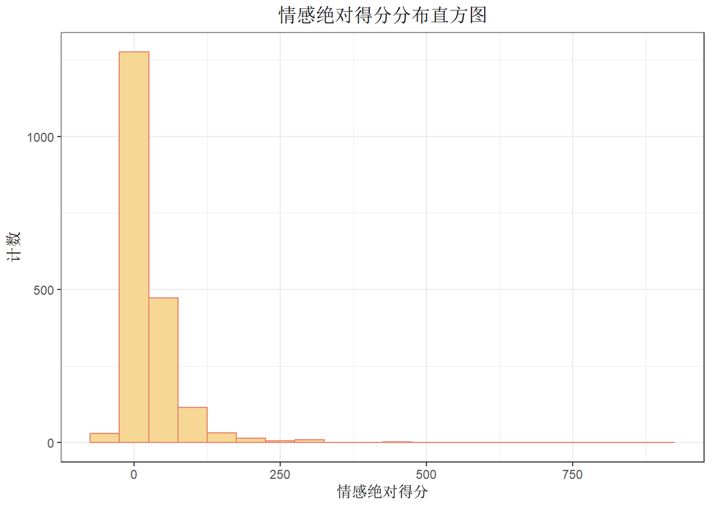

```r
score1.density <- ggplot(NULL, aes(news_data$"情感绝对得分")) +
  geom_histogram(binwidth = 50, colour='#e77f67', fill='#f7d794') +
  ggtitle("情感绝对得分分布直方图") +
  xlab("情感绝对得分") +
  ylab("计数") +
  theme_bw() +
  theme(plot.title = element_text(hjust = 0.5))

score1.density
```

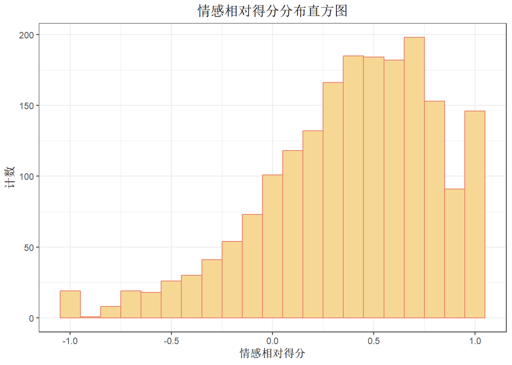

```r
score2.density <- ggplot(NULL, aes(news_data$"情感相对得分")) +
  geom_histogram(binwidth = 0.1, colour='#e77f67', fill='#f7d794') +
  ggtitle("情感相对得分分布直方图") +
  xlab("情感相对得分") +
  ylab("计数") +
  theme_bw() +
  theme(plot.title = element_text(hjust = 0.5))

score2.density
```

- 从情感得分的分布来看，情感偏正向的文章偏多。情感绝对得分由于呈现明显的右偏分布。

## 任务六：文本极性展示

展示情感得分最高和最低的几条文本

- 情感绝对得分最高的5条正向新闻

```r
positive.max.1 <- news_data[order(news_data$情感绝对得分, decreasing = TRUE),][1:5,]

kbl(positive.max.1) %>%          #查看数据
  kable_paper() %>%
  scroll_box(height = "500px")
```

|  | index | title | time | author | content | negative.count | positive.count | 情感绝对得分 | 情感相对得分 | polarity |
| --- | --- | --- | --- | --- | --- | --- | --- | --- | --- | --- |
| 91 | 91 | 指导新时代全面依法治国的纲领性文献 | 2021-2-28 21:04 | 和讯 | 指导新时代全面依法治国的纲领性文献 《求是》杂志编辑部 伟大时代孕育伟大理论，伟大思想引领伟大征程。推进全面依法治国是国家治理的一场深刻变革，必须以科学理论为指导，不断从理论和实践的结合上取得新成果，总结好、运用好党关于新时代加强法治建设的思想理论成果，更好指导全面依法治国各项工作。党的十八大以来，习近平总书记主持召开一系列重要会议、发表一系列重要讲话、作出一系列重要论断，深刻回答了为什么要全面依… | 113 | 1037 | 924 | 0.8034783 | 正向 |
| 554 | 554 | 坚定不移走中国特色社会主义法治道路 为全面建设社会主义现代化国家提供有力法治保障 | 2021-2-28 16:25 | 和讯 | 坚定不移走中国特色社会主义法治道路 为全面建设社会主义现代化国家提供有力法治保障 习近平 这次中央全面依法治国工作会议的主要任务是，总结经验，分析形势，明确任务，对当前和今后一个时期全面依法治国工作作出部署，动员全党全国全社会齐心协力，为深入推进全面依法治国、加快建设中国特色社会主义法治体系、建设社会主义法治国家而奋斗。 我们党历来重视法治建设。在新民主主义革命时期，我们党就制定了《中华苏维埃共和… | 125 | 752 | 627 | 0.7149373 | 正向 |
| 1957 | 1957 | 杨伟民牵头权威报告：如何把握”十四五规划”的大逻辑？ | 2021-2-27 0:10 | 和讯名家 | 2021年是“十四五”开局之年，是“两个一百年”奋斗目标的历史交汇期，意义重大！  为更好地把握“十四五”规划精神，洞察经济工作方向，中国财富管理50人论坛（CWM50）由“十四五”规划起草组成员、全国政协经济委员会副主任、CWM50学术顾问杨伟民牵头，CWM50理事长、全国政协经济委员会主任尚福林为顾问，组织撰写了《“十四五”规划精神解读与构建新发展格局的政策建议》报告（以下简称“… | 124 | 658 | 534 | 0.6828645 | 正向 |
| 1726 | 1726 | 《中国金融》｜魏革军：用习近平金融扶贫重要论述指导实践 | 2021-2-27 9:55 | 和讯名家 | C nfinance 编者按 2021年2月25日，习近平在全国脱贫攻坚总结表彰大会庄严宣告：我国脱贫攻坚战取得了全面胜利。值此之际，《中国金融》微信公众号再次分享“决战脱贫攻坚决胜全面小康”专栏文章，回顾金融系统在助力脱贫攻坚、全面建成小康社会道路上所做的贡献。 作者｜魏革军「中国人民银行西安分行行长」 文章｜《中国金融》2020年第17期 习近平金融扶贫重要论述的核心及总要求 习近平金融扶贫重… | 104 | 556 | 452 | 0.6848485 | 正向 |
| 953 | 953 | 中华人民共和国2020年国民经济和社会发展统计公报 | 2021-2-28 9:54 | 国家统计局 | 中华人民共和国2020年国民经济和社会发展统计公报 国家统计局 2021年2月28日 2020年是新中国历史上极不平凡的一年。面对严峻复杂的国际形势、艰巨繁重的国内改革发展稳定任务特别是新冠肺炎疫情的严重冲击，以习近平同志为核心的党中央统揽全局，保持战略定力，准确判断形势，精心谋划部署，果断采取行动，付出艰苦努力，及时作出统筹疫情防控和经济社会发展的重大决策。各地区各部门坚持以习近平新时代中国特色… | 214 | 642 | 428 | 0.5000000 | 正向 |

- 情感绝对得分最低的5条负向新闻

```r
negative.max.1 <- news_data[order(news_data$情感绝对得分, decreasing = FALSE),][1:5,]

kbl(negative.max.1) %>%          #查看数据
  kable_paper() %>%
  scroll_box(height = "500px")
```

|  | index | title | time | author | content | negative.count | positive.count | 情感绝对得分 | 情感相对得分 | polarity |
| --- | --- | --- | --- | --- | --- | --- | --- | --- | --- | --- |
| 268 | 268 | 林书豪被叫“新冠病毒”，美司法部调查“仇恨犯罪潮” | 2021-2-28 19:17 | 新京报 | 体育赛场上本应是最能体现公平、公正的地方，观众在为赛事的加油呐喊中感受到凝聚力与号召力。令人咂舌的是，最近的赛场却成为了公开歧视的场所。 近期，效力美国职业篮球发展联盟的亚裔球员林书豪在赛场上被另一位球员称为“新冠病毒”，引起舆论哗然。当地时间2月27日，美国职业篮球发展联盟宣布针对这起歧视事件展开调查。 然而，针对林书豪的歧视行为只是近期反亚裔仇恨事件的“冰山一角”。自从新冠肺炎危机暴发以来，包… | 125 | 52 | -73 | -0.4124294 | 负向 |
| 1022 | 1022 | 涉嫌非法集资，小霸王文化被查！曾画下500亿上市“大饼”，近50名投资人起诉“讨债” | 2021-2-28 8:08 | 和讯名家 | 新闻听着看，动态看，猛戳关注【每日经济新闻(博客,微博)视频号】△△△ 2月27日午间，广东省中山市公安局发布公告称，小霸王文化发展有限公司（以下简称小霸王文化）涉嫌非法吸收公众存款，目前正对此案开展全力侦查。 图片来源：微信截图 《每日经济新闻》记者注意到，小霸王文化是国民游戏机小霸王的品牌持有者益华集团的关联公司。目前，警方尚未披露小霸王文化涉嫌非法集资的具体情形，但记者了解到，2016年，小… | 130 | 58 | -72 | -0.3829787 | 负向 |
| 1515 | 1515 | *ST藏格风险全揭示：实控人涉非法采矿被逮捕 消息遮掩1个月股价两起两落 | 2021-2-27 12:37 | 电鳗快报 | 《电鳗快报》 文/李万钧 2月27日，*ST藏格(000408)集中披露实际控制人肖永明被批准逮捕、关于深交所关注函回复、部分资产及银行账户被查封冻结3份公告，该公司股价自1月下旬以来已经出现两次明显的拉升和回落，且交易量巨大。 《电鳗快报》研究发现，实控人的妻子和1名董事肖瑶(男)早在1月29日就已经知悉实控人被采取刑事拘留强制措施，而该公司其他董事和公司获悉此消息是在2月22日，实控人被拘留及… | 115 | 50 | -65 | -0.3939394 | 负向 |
| 1775 | 1775 | 库存持续累积 黑色金属进入调整 | 2021-2-27 9:18 | 新浪网 | 摘要： 钢材：随着春节临近，终端消费进入冰点，钢材贸易商和钢厂库存环比大幅上升，季节性累库持续，钢价继续调整。 铁矿石：1月末港口库存环比继续上升，但由于澳巴发运量持续下降，预计短期矿石供需双降库存增幅有限，而高基差限制矿价跌幅。 焦炭：由于年末产能的集中退出导致短期焦炭依旧供不应求，部分地区焦炭现货价格再次提涨100元，焦价累积上涨1000元/吨，吨焦利润超过980元/吨。但是钢价的调整及疫情的… | 90 | 33 | -57 | -0.4634146 | 负向 |
| 1845 | 1845 | 王一博、权志龙加你QQ？3名大学生骗走30多万，套路曝光… | 2021-2-27 8:12 | 和讯名家 | 2月23日，安徽省淮南市谢家集区人民法院公布3名大学生冒充多位明星进行诈骗的刑事判决书。 孙某、李某、刘某通过冒充王一博、权志龙、杨颖、迪丽热巴、赵丽颖、李现、欧阳娜娜等明星举办虚假返利活动进行诈骗，违法所得30余万元。3名被告均被判处有期徒刑并缴纳罚金。 圈套：QQ群上演“连环骗” 2018年底，被告人刘某加入“盛宴”家族群，网名“盛宴小绝”，通过群内聊天得知该群专门从事QQ诈骗，冒充明星的QQ… | 78 | 29 | -49 | -0.4579439 | 负向 |

- 情感相对得分最高的5条正向新闻

```r
positive.max.2 <- news_data[order(news_data$情感相对得分, news_data$positive.count, decreasing = TRUE),][1:5,]

kbl(positive.max.2) %>%          #查看数据
  kable_paper() %>%
  scroll_box(height = "500px")
```

|  | index | title | time | author | content | negative.count | positive.count | 情感绝对得分 | 情感相对得分 | polarity |
| --- | --- | --- | --- | --- | --- | --- | --- | --- | --- | --- |
| 1932 | 1932 | 李超：探索REITs与国家创新驱动战略有效结合 | 2021-2-27 0:16 | 证券时报 | 证券时报记者 吴少龙 2月25日，以“REITs聚势 产业乘风”为主题的大湾区基础设施REITs发展论坛在深交所举行。这是继去年8月基础设施公募REITs实务讨论会成功举办以来，深交所深入推进基础设施公募REITs试点工作，积极服务粤港澳大湾区和中国特色社会主义先行示范区建设的又一务实举措，进一步凝聚发展共识，促进市场形成合力，推动基础设施公募REITs试点行稳致远。 会议严格落实疫情防控工作要求… | 0 | 92 | 92 | 1 | 正向 |
| 692 | 692 | 全国人大代表司富春：道地中医药“走出去”还需拓宽通道 | 2021-2-28 14:29 | 中国新闻网 | (两会访谈)全国人大代表司富春：道地中医药“走出去”还需拓宽通道 中新网郑州2月28日电 (董飞 程洪力)2021年全国两会前夕，全国人大代表、河南中医药大学副校长司富春在接受记者采访时建言，拓宽中医药走出去的通道。 中医药是中华优秀传统文化的重要组成部分和典型代表，是中外交流友谊的“中国结”。已有的援外医疗、国际教育、科技合作、学术交流、中医药贸易等渠道形成了中医药走出去的有效途径。 “但加快中… | 0 | 49 | 49 | 1 | 正向 |
| 1451 | 1451 | 在国博与“月壤”面对面 | 2021-2-27 14:13 | 中国新闻网 | 中新网北京2月27日电 (记者 应妮)俗话说“十五的月亮十六圆”。嫦娥五号带回的月壤2月27日(正月十六)起在中国国家博物馆一展神秘容颜。 月壤 应妮 摄 2020年12月17日，嫦娥五号返回舱安全着陆，带回了近2公斤的月球样品，首次实现了我国地外天体采样返回，是航天强国建设征程中的重要里程碑。 入藏国博的月壤，正式名称为“月球样品001号”，其重量为100克。 展览现场 应妮 摄 据介绍，容纳月… | 0 | 44 | 44 | 1 | 正向 |
| 1236 | 1236 | 粤东江流域开展河湖巡查 协调解决跨界河湖问题 | 2021-2-27 18:51 | 中国新闻网 | 中新网广州2月27日电 (记者 王坚)记者27日从广东省水利厅获悉，广东省东江流域河长办2021年第一次专题会已举行。该办公室2021年东江流域河湖管理将进行“流域+区域”协同治水，不仅要全力做好东江省级河长服务保障工作，还要协助东江省级河长开展河湖巡查、协调解决跨界河湖问题。 广东省东江流域河长办主任、省东江流域管理局局长廖征红指出，东江作为该省四大水系之一，直接肩负着河源、惠州、东莞、广州东部… | 0 | 43 | 43 | 1 | 正向 |
| 1339 | 1339 | 建行重庆市分行多重好礼伴您欢乐闹元宵 | 2021-2-27 16:29 |  | 正月十五花灯俏，红红火火过大年。元宵佳节，建行重庆市分行为全市人民准备了多重好礼，涵盖吃喝玩乐各个方面，与您快快乐乐共度佳节。 鸿运当头，优惠不停！ 建行龙支付陪您闹元宵 龙粉福利会带来新人1元欢乐购，美团外卖20元红包、滴滴快车20元打车券、6包清风纸巾……通通都能1元带走；新老用户均可乐享京东E卡、KFC代金券等好礼随机立减1-9元，还可参与1分人气王，1分钱中大奖，快来参加吧！ 龙支付1元购… | 0 | 43 | 43 | 1 | 正向 |

- 情感相对得分最低的5条负向新闻

```r
negative.max.2 <- news_data[order(news_data$情感相对得分, -news_data$negative.count, decreasing = FALSE),][1:5,]

kbl(negative.max.2) %>%          #查看数据
  kable_paper() %>%
  scroll_box(height = "500px")
```

|  | index | title | time | author | content | negative.count | positive.count | 情感绝对得分 | 情感相对得分 | polarity |
| --- | --- | --- | --- | --- | --- | --- | --- | --- | --- | --- |
| 1813 | 1813 | 冷空气影响我国北方地区 中东部将出现大范围雨雪天气 | 2021-2-27 8:49 | 中国新闻网 | 中新网2月27日电 据中央气象台网站消息，预计，2月27日8时至3月1日8时，受冷空气影响，新疆南疆盆地、内蒙古大部、东北地区大部等地有5～7级风，阵风8～9级；气温下降6～12℃，局地可超过14℃。27日至3月1日，中东部地区将出现一次大范围雨雪过程，西北地区东部、华北西部和北部、东北地区将出现降雪或雨夹雪。 中新社记者 刘冉阳 摄 资料图：骑电动车的市民“全副武装”出行。中新社记者 刘冉阳 摄… | 23 | 0 | -23 | -1 | 负向 |
| 101 | 101 | 实拍内蒙古多地发射“火箭弹” 开启人工降雪模式 | 2021-2-28 20:58 | 中国新闻网 | 2月28日，内蒙古自西到东，几乎全部出现了降雪。为了获得更多的雨水，呼和浩特、包头、乌兰察布、鄂尔多斯(600295,股吧)、巴彦淖尔等地实施了“飞机+地面火箭”相结合的人工增雨(雪)作业，实施地面火箭作业以及发射火箭弹等。 此外，据气象部门消息显示，当天，内蒙古呼伦贝尔牙克石图里河镇最低气温下降至-35.7℃。(李爱平 陈峰） | 4 | 0 | -4 | -1 | 负向 |
| 1699 | 1699 | 美国新冠肺炎确诊病例超2846万例 | 2021-2-27 10:21 | 证券时报网 | 美国约翰斯·霍普金斯大学的统计数据显示，截至美东时间2月26日16时22分，美国新冠肺炎累计确诊病例已超过2846万例，达到28464252例；累计死亡病例超过50.9万例，达到509710例。 | 4 | 0 | -4 | -1 | 负向 |
| 380 | 380 | 俄罗斯新增新冠肺炎确诊病例11359例 累计确诊超过424万例 | 2021-2-28 18:13 | 证券时报网 | 证券时报网讯，央视新闻消息，据俄罗斯新冠病毒防疫官网发布的数据，截至莫斯科时间2月28日11时，过去24小时内俄罗斯新增新冠肺炎确诊病例11359例，累计确诊4246079例。新增治愈病例12391例，累计治愈3811797例。新增死亡病例379例，累计死亡86122例。 | 3 | 0 | -3 | -1 | 负向 |
| 1750 | 1750 | 长安汽车高层深夜回应代工华为汽车：假的 | 2021-2-27 9:31 | 财联社 | 财联社2月27日讯，针对长安汽车(000625,股吧)将代工华为自有品牌汽车，昨日深夜有长安汽车高层断然予以否认：“假的”。此外，据了解内情的行业人士表示，华为不可能推自有品牌汽车。（财联社记者 刘阳） | 3 | 0 | -3 | -1 | 负向 |